# Seasonality affects specialisation of a temperate forest herbivore community - Seifert - - Oikos - Wiley Online Library

[Oikos](https://onlinelibrary.wiley.com/journal/16000706)

[figure not shown]

Research

Full Access

# Seasonality affects specialisation of a temperate forest herbivore community

[Carlo L. Seifert](https://onlinelibrary.wiley.com/action/doSearch?ContribAuthorStored=Seifert%2C+Carlo+L),

[Leonardo R. Jorge](https://onlinelibrary.wiley.com/action/doSearch?ContribAuthorStored=Jorge%2C+Leonardo+R),

[Martin Volf](https://onlinelibrary.wiley.com/action/doSearch?ContribAuthorStored=Volf%2C+Martin),

[David L. Wagner](https://onlinelibrary.wiley.com/action/doSearch?ContribAuthorStored=Wagner%2C+David+L),

[Greg P. A. Lamarre](https://onlinelibrary.wiley.com/action/doSearch?ContribAuthorStored=Lamarre%2C+Greg+P+A),

[Scott E. Miller](https://onlinelibrary.wiley.com/action/doSearch?ContribAuthorStored=Miller%2C+Scott+E),

[Erika Gonzalez-Akre](https://onlinelibrary.wiley.com/action/doSearch?ContribAuthorStored=Gonzalez-Akre%2C+Erika),

[Kristina J. Anderson-Teixeira](https://onlinelibrary.wiley.com/action/doSearch?ContribAuthorStored=Anderson-Teixeira%2C+Kristina+J),

[Vojtěch Novotný](https://onlinelibrary.wiley.com/action/doSearch?ContribAuthorStored=Novotn%C3%BD%2C+Vojt%C4%9Bch),

First published: 15 June 2021

https://doi.org/10.1111/oik.08265

## Abstract

Understanding spatiotemporal trends on insect-plant interaction networks is essential to unveil the ecological and evolutionary processes driving herbivore specialisation. However, community studies accounting for temporal dynamics in host-plant specialisation of herbivorous insects are surprisingly scarce. Here, we investigated how seasonality affects specialisation of a temperate forest herbivore community. A substantial body of literature suggests that young plant foliage tends to be more protected by defence mechanisms effective against generalist insect herbivores than mature leaves. We thus hypothesised that herbivore specialisation would be highest in the early season, when young leaves are available, and that the degree of dietary specialisation would decline with leaf maturation. To test this hypothesis, we sampled more than 4700 folivorous caterpillars associated with 16 tree species within a 0.2 ha deciduous forest stand in eastern North America. We further examined the dietary specialisation of exposed feeders versus shelter builders (e.g. leaf rollers, leaf tiers, webbers). Contrary to our prediction, we observed a significantly less specialised herbivore fauna in the early season than in the two subsequent summer seasons. We further found that the seasonal increase in specialisation was driven by a remarkable turnover in species composition rather than by shifts in guild structure or intraspecific changes in diet breadth of the herbivores. These findings run counter to the widespread belief that young leaves are less susceptible to generalist insect herbivores. Our study underscores the need to account for temporal dynamics when contrasting herbivore specialisation among sites with pronounced seasonality.

## Introduction

Host-plant specialisation is a common element of insect–herbivore studies, and plays a key role in our understanding of species co-existence, speciation processes, diversity patterns, community assembly, and ecosystem functioning (Ehrlich and Raven 1964, Jaenike 1990, Novotný and Basset 2005, Lewinsohn and Roslin 2008, Winkler and Mitter 2008, Fordyce 2010, Forister et al. 2012, 2015, Becerra 2015, Hardy et al. 2020). Many studies on insect herbivore communities have aggregated host–plant associations and placed specialisation in either a spatial (Novotný et al. 2006, Dyer et al. 2007, Pellissier et al. 2012, Forister et al. 2015), functional (Novotný and Basset 1999, Novotný et al. 2010), or taxonomic context (Weiblen et al. 2006). The temporal dimension of specialisation, by contrast, has been widely neglected when studying antagonistic plant–insect interaction networks (Scherrer et al. 2016, Kemp et al. 2017, Wang et al. 2020). Plant–animal interaction networks, however, are dynamic systems (Lázaro et al. 2010, Schwarz et al. 2020, CaraDonna et al. 2021) that exhibit considerable annual and interannual variation. The study of temporal dynamics in host–plant associations may thus unveil new insights into ecological and evolutionary processes driving specialisation of insect herbivore communities.

In many ecosystems, communities of insect herbivores as well as their host plants display pronounced seasonality (Wolda 1988, Janzen 1993, Morais et al. 1999, Southwood et al. 2004, Diniz et al. 2012, Kishimoto-Yamada and Itioka 2015). In temperate realms for instance, lepidopteran larvae (caterpillars) often show marked seasonal variation in abundance, species richness, species composition, and feeding-guild structure (Summerville et al. 2003, Forkner et al. 2008, Šigut et al. 2018). As dietary specialisation differs strongly among insect herbivore taxa, such compositional turnover could lead to significant shifts in specialisation at the community level.

Host plants in temperate and other seasonal ecosystems change significantly in availability (e.g. foliage biomass), water content, nutritional quality, and defences over the course of the growing season (Feeny 1970, Murakami et al. 2005, Zehnder et al. 2009). Deciduous woody plants, especially those with determinate growth, provide young, nutrient-rich foliage primarily in spring, while mature leaves in the later seasons are generally of lower nutritional quality and often exhibit increased physical defences, e.g. toughness (Schultz et al. 1982, Lawson et al. 1984, Hunter and Lechowicz 1992, Murakami et al. 2005, Zehnder et al. 2009, Barber and Marquis 2011). Additionally, the composition of secondary metabolites in the foliage of woody plants changes considerably with leaf maturation (Salminen et al. 2004, Solar et al. 2006). Although some defensive compounds such as condensed tannins generally increase with leaf age in woody plant species (Forkner et al. 2004, Riipi et al. 2004, Murakami et al. 2005, Barber and Marquis 2011), young leaves are widely considered to be chemically better protected against insect herbivores (Valkama et al. 2004, Roslin and Salminen 2008, McCall and Fordyce 2010, Wiggins et al. 2016). Barton et al. (2019) showed in a meta-analysis across 124 woody tree species that concentrations of secondary metabolites significantly decrease during leaf maturation. The authors of this study further found that these metabolic shifts were stronger in species with determinate (synchronous) leaf flushing, which is commonly the case for deciduous trees in temperate regions. An increased investment in chemical defences when leaves are young aligns with optimal defence theory (ODT; McKey 1974, Rhoades 1979), which posits that young leaves should be better protected against herbivores as they have a greater fitness value than older leaves (Harper 1989). Due to their higher water content and nutritional quality, young leaves further represent a more attractive food source for insect herbivores than mature leaves and thus are more vulnerable to herbivory (Scriber 1977, Coley 1980, Kursar and Coley 2003, Wagner 2005).

As specialists are assumed to be better adapted to the defence mechanisms of their host plants, increased investment in leaf protection of young foliage should be more effective against generalist insect herbivores (Blüthgen and Metzner 2007, Roslin and Salminen 2008, Ali and Agrawal 2012). The seasonal changes in resource quality and defences may further lead to intraspecific shifts in host plant use by insect herbivores (Rausher 1981, Nylin 1988, Sandström 2000, Powell and Hardie 2001). Even though seasonal transitions are well documented for both plants and caterpillars, we lack documentation on how these temporal changes affect their interactions, and especially the specialisation patterns of insect herbivore communities.

In the present study, we investigated seasonal changes in specialisation of a temperate forest caterpillar community across two consecutive years. Caterpillars represent the largest fraction of leaf-chewing insects in forest ecosystems and thus contribute greatly to overall herbivory and nutrient cycling (Janzen 1988). In forests, the majority of caterpillar species (diversity and biomass) are associated with woody plants, relative to that of grass feeders, herb feeders, and those of alternative trophic associations (Strong et al. 1984, Hammond and Miller 1998, Summerville and Crist 2002, Wagner 2005, Wagner et al. 2011). Here, we focus on folivorous caterpillars associated with deciduous trees of a temperate deciduous forest. We divided the caterpillar fauna into two guilds according to their feeding behaviour: exposed feeders (free feeding; mostly macrolepidopterans) and shelter-builders (e.g. leaf rollers, leaf tiers, leaf folders; mostly microlepidopterans). Both guilds differ in terms of average specialisation with shelter-builders being generally more dietarily specialised than exposed feeders (Seifert et al. 2020). We examined seasonal changes in specialisation of the herbivore community within and across these two guilds.

By classifying the caterpillar community into three ‘seasonal communities', and by accounting for seasonal variations in resource composition and availability, we investigated how herbivore specialisation changed across the growing season. We hypothesise that dietary specialisation is greatest early in the season when tree foliage is of high nutritional value and assumed to be better protected by lineage-specific secondary metabolites effective against generalists. We further predicted that changes in specialisation might be driven by three mechanisms:

1. (i) Caterpillar species restricted to the early season (e.g. spring feeders) are overall more specialised than those restricted to either one or both of the later summer seasons;
2. (ii) Species richness and abundance of shelter-building caterpillars, which are overall more specialised at the study site (Seifert et al. 2020ab), decrease relative to exposed feeders over the growing season;
3. (iii) Specialisation of bi- and multivoltine species decreases over the growing season.

## Material and methods

### Study site and sampling

The study was conducted in a lowland deciduous forest in eastern North America, about 2.5 km east of Toms Brook (Shenandoah County, VA, USA; 38°55′N, 78°25′W; 220 m a.s.l.). This mature secondary forest stand represented an oak–hickory association, the most common forest type of the region (Rose 2016). Oaks *Quercus* spp., hickory *Carya* spp. and black gum *Nyssa sylvatica* comprised the dominant canopy tree species. Typical woody understory taxa were sassafras *Sassafras albidum*, flowering dogwood *Cornus florida* and common serviceberry *Amelanchier arborea*. Two species of the red oak complex (subgenus *Erythrobalanus*), namely *Quercus rubra* and *Quercus velutina*, hybridised at our study site. We therefore treated these two taxa as well as their hybrids as a single species complex hereafter named *Quercus rubra* agg.

Within a forest stand that had already been selected for logging by the owner, we set up two 0.1 ha plots, approximately 350 m away from each other, and censused 161 trees with a diameter at breast height (DBH) ≥ 5 cm. In order to ensure that no tree species was sampled only once, it was necessary to tag and sample 23 additional tree individuals in close proximity to the established plots. In total, 184 trees representing 16 species in 10 families (Supporting information) were sampled between the end of April and the end of August in 2016 and 2017. In both years, the sampling started at the onset of leaf flush.

Each study tree was felled and all externally feeding, folivorous lepidopteran larvae were collected immediately as detailed in Volf et al. (2019). The caterpillars were classified into feeding guild as either exposed feeders or shelter builders (e.g. leaf tiers, rollers and folders, case bearers), identified to species or morphospecies (hereafter termed ‘species'), and further processed as described in Seifert et al. (2020a). Caterpillar specimens and reared adults are deposited at the Institute of Entomology (České Budějovice, Czech Republic) and the Smithsonian National Museum of Natural History (Washington, D.C., USA), respectively.

To obtain information on resource availability, we quantified the sampled leaf area for every felled tree. First, we estimated the leaf area from a random subset of leaves taken from different crown parts. Based on leaf size, leaves were spread over two to four white frames of 50 × 50 cm. We then photographed this subset of leaves, calculated leaf area using ImageJ ver. 1.48 (Schneider et al. 2012), and lastly weighed the biomass of the sample. Second, we defoliated the tree to obtain an estimate of total leaf biomass (small trees: 100%, mid-size trees: 50%, and large trees: 25%). Finally, we extrapolated the leaf area of the sample to the trees' overall leaf biomass (details in Volf et al. 2019). Although resource availability could be alternatively measured as tree abundance or leaf biomass, we consider leaf area a better proxy as it accounts for differences in tree size (compared to abundance) and is more intuitive when used for calculating herbivore densities (individuals/unit area).

### Seasonality

In temperate forests, the abundance of leaf-chewing insect larvae peaks in spring as it coincides with the spring leaf flush, then drops off as leaves mature, before gradually increasing to a second peak in late summer (Feeny 1970, Forkner et al. 2004, Shutt et al. 2019, Volf et al. 2019). The drop in herbivore abundance after the spring peak largely coincides with the gradual decline in the availability of young foliage. Considering these general patterns in communities of insect herbivores and their hosts, we divided the sampling period into three parts, hereafter termed ‘early season' (26 April – 6 June), ‘midseason' (7 June – 18 July), and ‘late season' (19 July – 29 August). These periods do not strictly correspond to formal season definitions.

In both years, the end of the early season coincided with a prominent transition in resource availability/quality as afterwards young leaves were widely absent. Within each year of sampling, the proportion of young leaves dropped from 72% in the early season to < 1% in the midseason, while in the late season only mature leaves were available to caterpillars (Supporting information). Midseason and late-season samplings were intended to capture the abundance depression and late-summer peak of insect herbivores, respectively. The demarcation between those two seasons was chosen to coincide with the 6-week length of the spring season. As the overall sampling period across both years covered exactly 18 weeks (126 days), each of the defined seasons represents a period of 42 days. A finer-scale partitioning was not applied, to avoid an excessive reduction of plant–caterpillar interactions from the dataset and to ensure adequate sample robustness for the analyses.

For each season, we merged the herbivore data from both years and characterised the caterpillar community based on total abundance, density (individuals m<sup>−2</sup> sampled leaf area), species richness, and exclusivity. In order to estimate species richness for each season, we used the abundance-based, bias-corrected, Chao1 estimator (Chiu et al. 2014). Exclusivity was calculated as the proportion of species restricted to a particular season, relative to the total observed species richness across the 126-day sampling period.

### Caterpillar specialisation

Resource specialisation of caterpillars was calculated at the species level using the standardised distance-based specialisation index (DSI*; Jorge et al. 2014, 2017). Because resource richness, composition, and availability differed across the three sampling periods, we used DSI* rather than other measures of specialisation (e.g. host plant counts), which are highly sensitive to both variations in network size (number of interacting species) and sampling effort (Jorge et al. 2014, 2017). Values of DSI* range between −1 (maximum generalisation) and 1 (maximum specialisation). This index takes availability and phylogenetic relationships of the host plants into account and further considers interaction frequencies between consumer species (i.e. caterpillars) and their resources (i.e. host plant species), allowing for robust comparisons among interaction networks with different levels of resource composition and phylogenetic diversity (Redmond et al. 2019).

Resource availability of each host plant species was quantified as sampled leaf area within a particular season, summed across the two years. Phylogenetic relationships of the sampled tree species were estimated from a larger phylogeny of temperate tree species (Seifert et al. 2020ab), based on four loci: *rbcL*, *matK*, *ITS* and *trnL-trnF.* BEAST v2.4 was used to infer trees (Drummond et al. 2012); information on substitution models for individual loci, time calibration, and topology constraints can be found in Seifert et al. (2020b). This master phylogeny was pruned to a subtree that included only the focal tree species. For the red oak complex (*Quercus rubra* agg.) the phylogenetic position of *Quercus rubra* was used. Data on resource availability and phylogenetic relationships were used to calculate a specialisation index (DSI*) for the caterpillars present in each of the three seasons, excluding caterpillar species that were sampled only once within a particular season (n = 115 individuals, 2.4%).

### Statistical analyses

#### Seasonal trends in caterpillar specialisation

Our main hypothesis predicted that caterpillar specialisation is higher in the early season than in the midseason and late season. In order to test this hypothesis, we conducted linear mixed models (LMMs). Specialisation (DSI*) was used as the response variable; season and feeding guild were considered as fixed effects. Caterpillar species identity was used as a random effect to account for occurrences of a given species in multiple seasons. Observations were weighted by square-root-transformed caterpillar abundance to account for different sample sizes among species. We created models with either season or feeding guild, or both, as well as models including the interaction between season and guild. We ranked the models using the corrected Akaike information criterion (AICc) and selected the best model (ΔAICc ≤ 2 and the lowest number of parameters). The best model was compared with the null model including only the random effect and a fixed intercept by means of χ² likelihood-ratio test. A Tukey post hoc test was applied on the selected model to test for differences among seasons with Kenward–Roger approximations for the degrees of freedom. We further tested the robustness of the results by removing species that were sampled less than ten times in a particular season, and then repeated the LMM analysis described above. We additionally compared the LMMs with generalised linear mixed models (GLMMs) applying beta distribution and using DSI* values transformed into 0 < DSI* < 1. LMMs and GLMMs revealed similar results (not shown).

Further, we investigated if the observed patterns resulted from shifts in specialisation across the entire tree–caterpillar community or were driven by a single plant species or a few abundant herbivores. To do this, we analysed seasonal trends in specialisation of caterpillar assemblages associated with the most common tree species (based on sampled leaf area) and compared the seasonal trends in specialisation of abundant caterpillar families. To do so, we calculated the mean DSI across all caterpillar species associated with a particular tree (DSI*<sub>Host</sub>) as well as the mean DSI across all herbivore species belonging to a given caterpillar family (DSI*<sub>Fam</sub>).

In order to evaluate seasonal trends in caterpillar specialisation within host plant species, we examined those tree species for which we sampled ≥ 10 m<sup>2</sup> of leaf area in each of the seasons (S<sub>Tree</sub> = 8, N<sub>Tree</sub> = 156). We then conducted an LMM using mean specialisation (DSI*<sub>Host</sub>) of the abundance-weighted caterpillar community for each tree species as a response variable and season as a fixed effect. Tree species was used as a random effect as the within host plant trend in specialisation was the focus of this analysis. A Tukey post hoc test was applied to test for differences in DSI*<sub>Host</sub> among the seasons with Kenward–Roger approximations for the degrees of freedom.

In order to evaluate seasonal trends in specialisation within caterpillar families, we selected all families of which ≥ 25 individuals were sampled in each season (N<sub>Fam</sub> = 7, N<sub>Cat</sub> = 3603). For each family, the abundance-weighted mean specialisation (DSI*<sub>Fam</sub>) per season was calculated. We then conducted an LMM using mean specialisation of the caterpillar families (DSI*<sub>Fam</sub>) as the response variable and season as a fixed effect. Caterpillar family was used as a random effect as the within-family trend in specialisation was the focus of this analysis. A Tukey post hoc test was applied to test for differences in mean specialisation of the selected caterpillar families among seasons with Kenward–Roger approximations for the degrees of freedom.

As temporal variation in herbivore specialisation could be driven by: 1) taxonomic turnover among the seasons; 2) changes in guild structure if these differed in their degree of specialisation, and/or; 3) intraspecific changes in specialisation of bi- or multivoltine caterpillar species among their generations, we studied each of these mechanisms to evaluate their effects on seasonal shifts in caterpillar specialisation.

#### Seasonal trends in species composition

We first calculated the compositional turnover of the whole caterpillar community among seasons. As sample sizes among seasons differed due to seasonal variations in caterpillar abundances, we used Morisita–Horn similarities (MH) to calculate the temporal turnover in species composition. This abundance-based similarity index is robust for comparisons among samples of different size due to its low sensitivity to rare or uncommon species (Wolda 1981, Beck et al. 2013).

We then tested the first mechanism which assumes that specialisation of caterpillar species restricted to the early season differs from those species restricted to the midseason and/or late season. This approach divides the caterpillar community into an assemblage with access to young foliage (early season species), and two assemblages of species that feed almost exclusively on mature foliage during their development. To make this comparison, we excluded all caterpillar taxa from the dataset that occur in spring and in one or both of the two later seasons as these species are not necessarily exposed to only either young or mature leaves. Including only the remaining species, we then performed a set of LMMs with specialisation (DSI*) as the response variable, and season and feeding guild as fixed effects. Observations were weighted by square-root transformed caterpillar abundance to account for different sample numbers among species. We created models with either or both season and feeding guild, as well as including the interaction between them. A Tukey post hoc test was used to test for differences in specialisation among the seasons (Kenward–Roger approximations for the degrees of freedom). The LMM analyses revealed similar results as GLMMs using standardised DSI* values (0 < DSI* < 1) and a beta distribution (results not shown).

#### Seasonal trends in guild structure

Here, we tested our second mechanism which assumed that seasonal changes in specialisation are driven by shifts in guild composition. To do so, we tested for proportional shifts in abundance and richness of the contrasted feeding guilds (exposed feeders versus shelter builders) across the three seasons by fitting two generalised linear models (GLMs) with a binomial error distribution. To test for seasonal changes in guild abundance, the proportion of individuals belonging to each guild was used as response variable and season as the predictor variable. In order to test for seasonal changes in guild richness, the proportion of species belonging to each guild was used as the response variable and season as the predictor variable. Both models were compared to a null model using ANOVAs. In case of significance, a Tukey post hoc test was further applied to test for differences in guild structure between each pair of seasons.

#### Intraspecific shifts in specialisation

Our third mechanism assumed that seasonal shifts in specialisation were driven by intraspecific changes in host specificity of bi- or multivoltine species. In order to test this assumption, we selected all caterpillar species that occur in the early season and one or both of the later seasons. We then excluded all single-brooded species based on our field observations and available literature (Wagner et al. 1998, 2001, 2011, Wagner 2005, Marquis et al. 2019). The remaining fraction of species was used for the analyses (Supporting information). We then performed a set of LMMs using specialisation (DSI*) as the response variable; season and feeding guild were considered as fixed effects. Observations were weighted by square-root transformed caterpillar abundance to account for different sample numbers among species. We created models with either or both season and feeding guild, as well as including the interaction between them. A Tukey post hoc test was performed to test for differences in specialisation across/among seasons. The LMM analyses revealed similar results than the GLMMs using standardised DSI* values (0 < DSI* < 1) and a beta distribution (results not shown).

All statistical analyses were performed in R environment (R ver. 4.0.2; <[www.r-project.org](http://www.r-project.org/)>). Linear mixed models were built and analysed using the *lme4* package (Bates et al. 2015). Tukey post hoc tests were conducted using the *emmeans* package (Lenth 2020). Indices of compositional turnover and richness estimates were calculated using the *vegan* package (Oksanen et al. 2019).

## Results

### The caterpillar community

Across seasons, 4710 caterpillars, belonging to 243 species and 25 families, were sampled. Ranked by caterpillar abundance, Tortricidae, Noctuidae and Depressariidae dominated the spring fauna. In the midseason, Depressariidae, Notodontidae and Noctuidae were the most abundant families, whereas the late season was dominated by Depressariidae, Notodontidae and Erebidae (Supporting information). The most speciose family in early season was Geometridae, followed by Tortricidae and Noctuidae, while for the mid and late-season Noctuidae, Geometridae, and Erebidae accounted for the greatest proportions of taxonomic richness (Supporting information).

Most of the caterpillar individuals and species were collected in the early and late season; both richness and abundance were distinctly lower for the midseason (Table 1). Chao1 estimates revealed similar proportions of observed species for early season, midseason, and late season, indicating an equal sampling coverage of the three communities (Table 1). Caterpillar density was highest in the late season, followed by early season and midseason. Exclusivity (E<sub>S</sub>), indicating the proportion of species collected in only one of the seasons, was overall high (65.8%, 160 spp.; Table 1). Twenty-nine species (11.9%) were observed in all three seasons (Supporting information).

Table 1. Abundance (N), density (D, individuals m<sup>-2</sup> leaf area), observed and estimated richness (S<sub>Obs</sub> and S<sub>Chao</sub>), and exclusivity (E<sub>S</sub>) for caterpillar assemblages collected across three six-week time periods in a mixed deciduous oak–hickory forest in Virginia, USA

| Season | N | D [N m<sup>–</sup><sup>2</sup>] | S<sub>Obs</sub> | S<sub>Chao</sub> (± SE) | (E<sub>S</sub>) |
| --- | --- | --- | --- | --- | --- |
| Early season | 1877 | 0.97 | 132 | 181.3 ± 19.4 | 0.33 |
| Midseason | 620 | 0.79 | 94 | 121.6 ± 12.9 | 0.10 |
| Late season | 2213 | 1.74 | 129 | 170.6 ± 18.3 | 0.23 |
| Across seasons | 4710 | 1.18 | 243 | 300.2 ± 19.3 | 0.66 |

### Seasonal trends in caterpillar specialisation

By testing our main hypothesis, we found specialisation of the caterpillar community to be significantly affected by both season and feeding guild (χ<sup>2</sup><sub>6</sub> = 30.83, p < 0.001; Fig. 1, Supporting information). Contrary to expectation, the spring fauna was less dietarily specialised than the caterpillar communities of the midseason (t<sub>1201</sub> = −2.921, p = 0.01) and late season (t<sub>1292</sub> = −4.198, p < 0.001). The significant difference between early and late season was retained when species observations with less than ten individuals for a given season were excluded from the analyses (t<sub>782</sub> = −4.068, p < 0.001; Supporting information). Both analyses showed that exposed feeders were less specialised than the shelter-builders (p < 0.001).

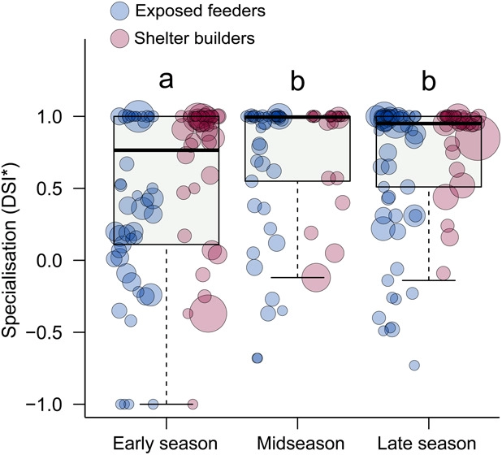

**Figure 1**

Seasonal trends in specialisation of a temperate forest caterpillar community in eastern North America. Each circle represents a species classified by feeding guild; circle size indicates proportional abundance (square-root transformed).

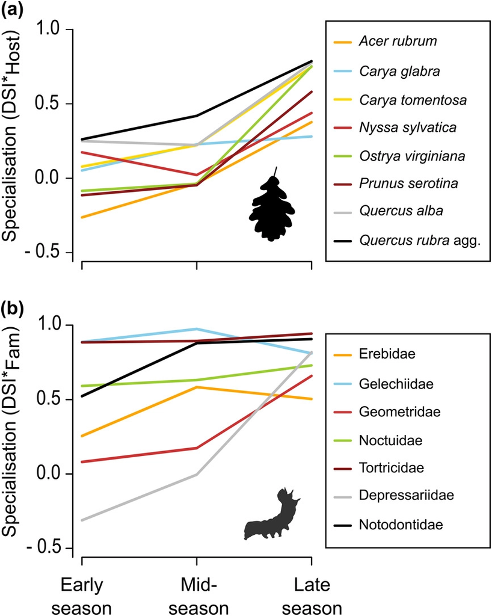

**Figure 2**

Seasonal trends in mean specialisation of (a) caterpillar assemblages associated with target tree species (DSI*<sub>Host</sub>), and (b) focal caterpillar families (DSI*<sub>Fam</sub>).

### Seasonal trends in species composition

The compositional similarity of caterpillar communities was highest between early season and midseason (MH = 0.68); faunal overlap between midseason and late season was remarkably lower (MH = 0.21). The highest compositional turnover was found between the early and late season caterpillar faunas (MH = 0.08). When testing for the effect of compositional turnover, we found the assemblage of caterpillar species restricted to the early season to be significantly less specialised than those assemblages occurring in the midseason (t<sub>766</sub> = −3.289, p = 0.003) and/ or late season (t<sub>1004</sub> = −3.297, p = 0.0029; Fig. 3, Supporting information).

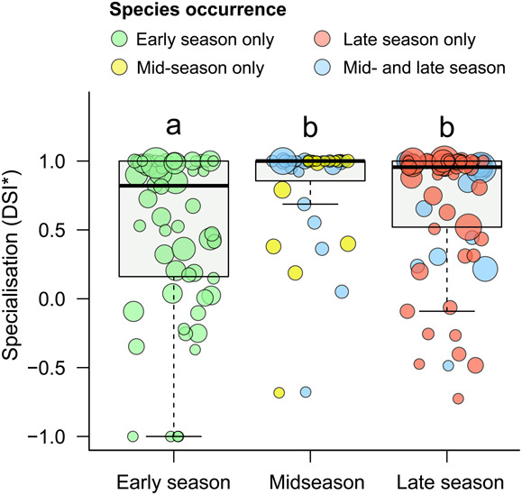

**Figure 3**

Seasonal changes in specialisation among the caterpillar fauna restricted to the early season and assemblages occurring in the mid-season and/or late season. Each circle represents a species; circle size indicates proportional abundance (square-root transformed).

### Seasonal trends in guild structure

Based on caterpillar abundance, shelter-builders dominated the early and late season (61.0% and 59.5%, respectively), while the proportions of exposed feeders and shelter builders were almost balanced in the midseason (53.7% versus 46.3%, respectively; Supporting information). The highest richness for shelter-builders was found in the early season (63 spp.), while exposed feeders showed their highest richness in the late season (81 spp., Supporting information). The lowest richness for exposed feeders and shelter-builders was observed in the midseason (61 and 33 spp., respectively). The GLM based on caterpillar abundance revealed significant changes in guild structure across seasons (df = 2, deviance = 43.067, p < 0.001). Guild structure changed significantly between early season and midseason (z = −6.38, p < 0.001), and again between midseason and late season (z = 5.82, p < 0.001), while no significant change in guild composition was found between early season and late season (z = −0.999, p = 0.577). For species richness, proportional changes in guild structure among the seasons were not significant (df = 2, deviance = 4.5564, p = 0.102).

### Intraspecific shifts in specialisation

When testing for the effect of intraspecific shifts in host specificity, the best model included only feeding guild, indicating that specialisation of bi- or multivoltine species did not differ significantly across seasons (Supporting information).

## Discussion

In the present study, we investigated how seasonality influences dietary specialisation of insect–herbivore communities. Our results show that the dietary specialisation of herbivores of a temperate forest community can change significantly over the course of a single growing season. Contrary to our predictions, specialisation of the caterpillar fauna was significantly lower in the early season than in the mid and late seasons. The seasonal change in caterpillar specialisation was found to be driven by the turnover in species composition rather than by guild structure or intraspecific shifts in diet breadth. To the best of our knowledge, this is the first study to quantitatively test seasonal changes in specialisation of antagonistic plant–herbivore interaction networks in a temperate forest ecosystem and usefully complements previous research from tropical and subtropical areas (Scherrer et al. 2016, Kemp et al. 2017, Wang et al. 2020).

Our main hypothesis predicted a decrease in caterpillar dietary specialisation over the course of the growing season. Surprisingly, we found the opposite, i.e. that the early season caterpillar fauna was significantly less specialised compared to the caterpillar assemblages of the midseason and late season. The pronounced difference in specialisation between the early and late-season fauna was retained, when we excluded species observations of less than ten individuals for a given season. Additional analyses on focal tree and herbivore taxa showed that the difference in specialisation between early and late season was not driven by a single tree species or caterpillar taxon.

We used our data to distinguish among three mechanisms that could account for the observed seasonal changes: 1) taxonomic turnover; 2) changes in guild composition, or; 3) intraspecific changes in specialisation of bi- and multivoltine species. We documented a high turnover in species composition at our study site, a mid-latitude, mixed, deciduous forest. Marked changes in community composition across the growing season are characteristic for Lepidoptera communities in seasonal environments, and particularly well documented for temperate regions (Summerville and Crist 2003, Murakami et al. 2005, 2007, Highland et al. 2013). The seasonal turnover in taxonomic composition at our study site, included a shift in caterpillar specialisation. However, contrary to our prediction, caterpillar species restricted to the early season were significantly less specialised than those restricted to the midseason and/or late season, which matched our findings on the overall caterpillar community (full dataset). Nevertheless, high species turnover does not necessarily imply significant shifts in specialisation (Kemp et al. 2017, Redmond et al. 2019). For example, we did not detect specialisation differences between the mid and late-season caterpillar assemblages in our study, although the compositional turnover among those two seasons was high.

Our second mechanism predicted proportions of shelter-builders, which are more specialised than exposed feeders (Seifert et al. 2020ab), to decline further into the growing season. However, proportional abundances of shelter-builders were only found to decrease in midseason. Shelter-builder richness, by contrast, was highest in the early season and declined afterwards, although not significantly. Thus, contrary to our second mechanism, differences in guild composition did not explain the seasonal changes in caterpillar specialisation (although we did find important differences in the taxonomic composition of the shelter-builders between early and late-season samples, Supporting information). Leaf-rollers and leaf folders are most diverse in the early season when young (pliable) leaves are available (Forkner et al. 2008). The late-season, shelter-formers, composed primarily of leaf tiers and webbers, such as *Machimia tentoriferella*, *Psilocorsis reflexella* and *Pococera* spp., are notable for their abilities to manipulate mature leaves. The toughness of mature tree foliage represents a biomechanical constraint that prevents many microlepidopteran caterpillars (which includes almost all shelter-builders) from having the physical or behavioural capacity to close, and thereby secure their shelters. We know of no caterpillars that can roll mature oak leaves, whereas the spring leaf-roller fauna on oaks in our study includes no less than 30 species of ‘leaf-rollers' representing several families. Instead, the late-summer caterpillars use silk to form their shelters between overlapping leaves, pinch and silk over shallow depressions, or form messy nests (that includes their frass).

Contrary to our third predicted mechanism, there was no seasonal effect on specialisation of bi- and multivoltine species. Stated differently, we found no evidence that diet breadth differed across the generations of multi-brooded species. However, host–plant associations, and thus preferences, were occasionally observed to change between broods of a particular caterpillar species.

Taken together, our results strongly suggest that seasonal variation in herbivore specialisation is due to the replacement of univoltine, generalised early season feeders by more specialised species restricted to the mid and/or late season. As shown, the transition from the early season to the midseason suggested a prominent shift in resource availability from young to mature leaves. Thus, our results indicate that specialisation of caterpillar assemblages was positively correlated with degree of leaf maturation, which further explains why no significant difference in specialisation was found between midseason and late season. Our results are contrary to findings by Scherrer et al. (2016), who observed increased caterpillar specialisation in the rainy season of the Brazilian cerrado, when young leaves are available. As in our study, Wang et al. (2020) reported higher specialisation for late-season caterpillar assemblages in a subtropical Chinese forest.

Deciduous trees and evergreen woody plants exhibit distinct phenology and leaf syndromes at least in part to discourage insect herbivores (Pringle et al. 2011, Silva et al. 2015) that in turn trigger turnover in the herbivore fauna. We wonder if the differing seasonal effects on herbivore specialisation reported by Scherrer et al. (2016) were the result of changing proportions of evergreen species within the studied plant community, or in some other way related to the radically different host plant associations of the Brazilian cerrado.

Leaves of deciduous trees undergo a considerable change in structural traits and chemistry over the course of a growing season. Mature leaves are of significantly lower nutritional value, lower water content, and tougher compared to young leaves (Schultz et al. 1982, Haukioja et al. 2002, Murakami et al. 2005, Zehnder et al. 2009, Barber and Marquis 2011). In both temperate and tropical woody plants, concentrations of condensed tannins increase over the course of leaf maturation (Riipi et al. 2004, Salminen et al. 2004), while many other secondary metabolites may decline or disappear (Baldwin et al. 1987, Riipi et al. 2004, Salminen et al. 2004, Roslin and Salminen 2008). ODT (McKey 1974, Rhoades 1979) predicts that young leaves are better protected against insect herbivores than mature leaves (McCall and Fordyce 2010). As specialists should be better adapted to defences of their host plants than generalists (Forkner et al. 2004, Roslin and Salminen 2008, Ali and Agrawal 2012), one would predict that caterpillar specialisation should be higher in the early season when young leaves are in abundance (Niemelä 1983, Roslin and Salminen 2008). Our results, however, indicate that traits present in mature leaves may promote specialisation in caterpillars. Leaf toughness, for instance, represents a strong barrier, especially for neonates, early instars, and many shelter-formers (Despland 2018).

Condensed tannins show pronounced diversity in woody plant species, even among congeners (Ayres et al. 1997), and were found to negatively affect the development time, fitness, and survival rate of insect herbivores (Feeny 1970, Ayres et al. 1997, Forkner et al. 2004, Roslin and Salminen 2008). Similarly, negative effects on insect herbivores were reported for low-quality plants in terms of water and nitrogen availability (Awmack and Leather 2002, Haukioja et al. 2002). Differences in leaf quality and defensive traits also limit the availability of suitable hosts even for highly polyphagous caterpillars (Lill et al. 2009, Pearse 2011). In sum, the constraints posed by mature leaves may lead to heretofore underappreciated dietary specialisation in caterpillar assemblages.

Besides the temporal changes in leaf nutritional quality and defences, seasonal variations in resource predictability (leaf phenology), are likely to have strengthened the observed pattern in specialisation. Deciduous tree species show strong interannual and intraannual variations in their timing of leaf emergence (Rousi and Heinonen 2007, Morin et al. 2009, Polgar and Primack 2011, Donnelly et al. 2017). Consequently, their leaves represent less predictable resources for early season herbivores than later in the vegetation period, when leaf quality, availability, and defences are highly predictable. Pronounced polyphagy among early season feeders, as observed in our study, thus supports the resource predictability hypothesis, which assumes that increased host–plant predictability promotes specialisation of associated insect herbivores (Cates 1981, Novotný 1994).

Apart from bottom–up effects, top–down control by natural enemies could also drive host-plant specialisation in herbivorous insect communities (Bernays and Graham 1988, Lill et al. 2002). For instance, parasitism as well as predation pressure by birds and ants vary among tree species (Lill et al. 2002, Singer et al. 2012, 2014, Drozdová et al. 2013) and change during the growing season (Le Corff et al. 2000, Remmel et al. 2009, Drozdová et al. 2013, Šigut et al. 2018). The caterpillar development time, and thus their exposure to natural enemies, strongly depends on host plant quality. Following, seasonal differences of enemy-reduced space (i.e. host plants) might have driven the observed seasonal patterns in herbivore specialisation. However, accounting for seasonal effects of the third trophic level was beyond the scope of our study and represents an interesting topic for future research.

## Concluding remarks

We demonstrate that seasonality can strongly influence dietary specialisation of herbivore communities in temperate deciduous forests. We found that a considerable fraction of caterpillars restricted to the early season were replaced by more specialised species in the mid and late season. We hypothesise that a set of various bottom–up effects, e.g. changes in nutritional quality, defensive traits, and resource predictability (leaf phenology), are driving the seasonal changes in dietary specialisation that we studied. We found support for the resource predictability hypothesis, but no evidence that young leaves are better protected against generalist herbivores, as derived from assumptions of the optimal defence theory. From a methodological point of view, our study highlights the need to account for seasonal variations when specialisation of herbivore communities is compared across sites with marked seasonality. If herbivore communities are sampled in different times of the growing season, spatial and temporal effects driving specialisation patterns may be conflated. As an example, many herbivore studies from temperate areas are timed to cover the abundance peak in spring. These studies overlook the assemblage of species restricted to later seasons, which can differ substantially in their functional traits such as diet breadth.

Future studies might investigate the relative contribution of individual plant traits responsible for seasonal changes in specialisation of herbivore communities. While much existing literature has focused on the importance of secondary metabolites in newly issuing foliage to herbivory, perhaps leaf nutritional quality, water content, and toughness are affecting herbivore specialisation to an appreciably greater degree than previously thought. And as noted above, the role that predators and parasitoids might play in driving the observed pattern reported here remains unexplored.

Few studies have examined temporal aspects of dietary specialisation in insect herbivores and the present study provides first insights for a temperate forest caterpillar community.

Our sampling covered only two consecutive years. Thus, we were not able to account for temporal dynamics at larger scales. Long-term sampling programs across multiple consecutive years would allow for interannual comparisons and further provide insights to what extent herbivore specialisation varies within a particular season, and to what degree this lowers or strengthens interseasonal differences. Further, the present study was restricted to a single forest. Therefore, additional spatial investigations are needed to ascertain the generality of our findings to other regions, forest types, and ecosystems.

*Acknowledgements* – We are grateful to the staff, interns, and volunteers of the Smithsonian Conservation Biology Institute (Front Royal, VA, USA) and the Biology Centre of the Czech Academy of Sciences (České Budějovice, Czech Republic) who assisted with field work, especially G. Carscallen, M. E. Losada, and G. Nichols for their efforts in processing the caterpillar samples. We thank J. Rhodes for permission to conduct the field work on his property. J. Brown, D. Davis, R. Robbins, and N. Silverson (Smithsonian), P. Goldstein (US Dept of Agriculture), and M. Epstein (California Dept of Food and Agriculture) provided help with identifications. We further thank our colleagues at the Canadian Center for COI-sequencing hundreds of caterpillar specimens.

*Funding* – This study was funded by the European Research Council (ERC grant No. 669609). GPAL was supported by Junior GAČR grant (19-15645Y). MV was funded by the Grant Agency of the Czech Republic (20-10543Y) and by the Czech Academy of Sciences within the Programme for Research and Mobility Support of Starting Researchers (MSM200962004).

*Conflicts of interest* – The authors declare no conflicts of interest.

### Author contributions

**Carlo L. Seifert**: Conceptualization (lead); Data curation (lead); Formal analysis (lead); Investigation (lead); Methodology (lead); Validation (equal); Visualization (lead); Writing – original draft (lead). **Leonardo R. Jorge**: Conceptualization (equal); Formal analysis (supporting); Methodology (supporting); Validation (equal); Visualization (supporting); Writing – original draft (supporting). **Martin Volf**: Investigation (supporting); Methodology (supporting); Validation (equal); Visualization (supporting). **David L. Wagner**: Methodology (supporting); Validation (equal); Writing – original draft (supporting). **Greg P. A. Lamarre**: Data curation (supporting); Investigation (equal); Validation (equal). **Scott E. Miller**: Data curation (supporting); Investigation (supporting); Project administration (supporting); Resources (supporting); Validation (equal). **Erika Gonzalez-Akre**: Data curation (supporting); Investigation (supporting); Project administration (supporting); Resources (supporting); Validation (equal). **Kristina J. Anderson-Teixeira**: Project administration (supporting); Resources (supporting); Validation (equal). **Vojtêch Novotný**: Funding acquisition (lead); Investigation (supporting); Methodology (equal); Project administration (lead); Resources (lead); Supervision (lead); Validation (equal).

[figure not shown]

Online Version of Record before inclusion in an issue

### Details

© 2021 Nordic Society Oikos. Published by John Wiley & Sons Ltd

### Keywords

- caterpillars
- [deciduous forests](https://onlinelibrary.wiley.com/action/doSearch?field1=Keyword&text1=deciduous%20forests)
- [feeding guilds](https://onlinelibrary.wiley.com/action/doSearch?field1=Keyword&text1=feeding%20guilds)
- [insect herbivores](https://onlinelibrary.wiley.com/action/doSearch?field1=Keyword&text1=insect%20herbivores)
- [interaction networks](https://onlinelibrary.wiley.com/action/doSearch?field1=Keyword&text1=interaction%20networks)
- [leaf nutritional quality](https://onlinelibrary.wiley.com/action/doSearch?field1=Keyword&text1=leaf%20nutritional%20quality)
- phenology
- [plant defences](https://onlinelibrary.wiley.com/action/doSearch?field1=Keyword&text1=plant%20defences)

### Publication History

- Version of Record online: 15 June 2021
- Manuscript accepted: 15 May 2021